# HomeLLC Assessment

```python
import pandas as pd
import numpy as np
import matplotlib.pyplot as plt
import seaborn as sns
```

```python
path='..\\files\\HomeLLC.xls'
```

```python
df=pd.read_excel(path)
```

```python
df.head()
```

|  | observation_date | Interest_rates | Averagehourlyearning-Construction | Building_permits | PCE(In billions) | StickyCPI Index | Total Construction Spending(in millions) | Unemployment_rate | Male unemployment rate | Female unemployment rate | Average monthly rent(primary residence) | Male working age population | Female working age population | Average family income | Real Estate Investment | GDP | Total Housing Units | Average house sale price | Homeprice INDEX |
| --- | --- | --- | --- | --- | --- | --- | --- | --- | --- | --- | --- | --- | --- | --- | --- | --- | --- | --- | --- |
| 0 | 2003-01-01 00:00:00 | 1.488202 | NaN | 1808.0 | 7541.3 | 0.223929 | 863855.0 | 5.8 | 6.2 | 5.4 | 203.2 | 1.001563e+08 | 104805250.0 | 68560.0 | 2083.097143 | 11174.129 | 120792.0 | 186000.0 | 128.461 |
| 1 | 2003-02-01 00:00:00 | 1.466379 | NaN | 1854.0 | 7548.6 | 0.178930 | 859225.0 | 5.9 | 6.1 | 5.6 | 203.5 | 1.001563e+08 | 104805250.0 | 68560.0 | 2066.608947 | 11174.129 | 120792.0 | 186000.0 | 129.356 |
| 2 | 2003-03-01 00:00:00 | 1.223591 | NaN | 1757.0 | 7611.5 | 0.134679 | 851132.0 | 5.9 | 6.1 | 5.7 | 204.0 | 1.001563e+08 | 104805250.0 | 68560.0 | 2120.850000 | 11174.129 | 120792.0 | 186000.0 | 130.148 |
| 3 | 2003-04-01 00:00:00 | 1.309618 | NaN | 1803.0 | 7634.5 | 0.095053 | 859459.0 | 6.0 | 6.4 | 5.7 | 204.5 | 1.001563e+08 | 104805250.0 | 68560.0 | 2234.471905 | 11312.766 | 121233.0 | 191800.0 | 130.884 |
| 4 | 2003-05-01 00:00:00 | 1.370721 | NaN | 1835.0 | 7650.3 | 0.148913 | 866814.0 | 6.1 | 6.4 | 5.7 | 205.0 | 1.001563e+08 | 104805250.0 | 68560.0 | 2342.642857 | 11312.766 | 121233.0 | 191800.0 | 131.734 |

# Data Definition

### Interest_rates:

The real interest rate refers to the nominal interest rate adjusted for inflation. In other words, it represents the actual purchasing power of interest earned or paid on an investment or loan. The real interest rate is crucial for assessing the true cost of borrowing or the real return on an investment.

### Averagehourlyearning-Construction:

The average hourly earnings for workers in the construction industry.

### Building_permits:

The number of permits issued for new construction or significant alterations to existing structures.

### PCE(In billions):

Personal Consumption Expenditure, representing the total value of goods and services consumed by individuals in billions of dollars.

### StickyCPI Index:

The Consumer Price Index (CPI) that measures the average change over time in the prices paid by urban consumers for a market basket of consumer goods and services, with a focus on items that change slowly.

### Total Construction Spending(in millions):

The total expenditure on construction activities in millions of dollars.

### Unemployment_rate:

The percentage of the labor force that is unemployed and actively seeking employment.

### Male unemployment rate:

The unemployment rate specifically for male individuals in the labor force.

### Female unemployment rate:

The unemployment rate specifically for female individuals in the labor force.

### Average monthly rent(primary residence):

The average monthly rental cost for primary residences.

### Male working age population:

The count or percentage of the male population within the working-age range.

### Female working age population:

The count or percentage of the female population within the working-age range.

### Average family income:

The mean income earned by families.

### Real Estate Investment:

The amount of money invested in real estate properties.

### GDP:

Gross Domestic Product, the total value of all goods and services produced in a country within a specific time period.

### Total Housing Units:

The total number of housing units, which can include houses, apartments, and other types of dwellings.

### Average house sale price:

The mean price at which houses are sold.

### Home price INDEX:

An index that measures the relative changes in residential property prices over time.

```python
df.describe()
```

|  | Interest_rates | Averagehourlyearning-Construction | Building_permits | PCE(In billions) | StickyCPI Index | Total Construction Spending(in millions) | Unemployment_rate | Male unemployment rate | Female unemployment rate | Average monthly rent(primary residence) | Male working age population | Female working age population | Average family income | Real Estate Investment | GDP | Total Housing Units | Average house sale price | Homeprice INDEX |
| --- | --- | --- | --- | --- | --- | --- | --- | --- | --- | --- | --- | --- | --- | --- | --- | --- | --- | --- |
| count | 250.000000 | 212.000000 | 250.00000 | 250.000000 | 250.000000 | 2.500000e+02 | 250.000000 | 250.000000 | 250.000000 | 250.000000 | 2.400000e+02 | 2.400000e+02 | 240.000000 | 250.000000 | 250.000000 | 250.000000 | 250.00000 | 250.000000 |
| mean | 0.944027 | 27.965330 | 1315.29600 | 11943.058800 | 0.216105 | 1.183392e+06 | 5.916400 | 6.105200 | 5.698800 | 279.677992 | 1.101715e+08 | 1.148255e+08 | 91229.500000 | 7372.860765 | 17657.406396 | 133767.100000 | 285062.00000 | 185.591492 |
| std | 0.718677 | 3.826403 | 471.15415 | 2857.528373 | 0.114106 | 3.161009e+05 | 2.047726 | 2.211328 | 1.916185 | 52.657161 | 5.503875e+06 | 5.901726e+06 | 17477.211599 | 3425.809965 | 4212.596226 | 6303.223652 | 70832.11638 | 47.137670 |
| min | -0.407134 | 21.850000 | 513.00000 | 7541.300000 | -0.162080 | 7.583760e+05 | 3.400000 | 3.400000 | 3.300000 | 203.200000 | 1.001563e+08 | 1.048052e+08 | 68560.000000 | 1934.748636 | 11174.129000 | 120792.000000 | 186000.00000 | 128.461000 |
| 25% | 0.420115 | 25.185000 | 998.50000 | 9848.500000 | 0.151229 | 9.299162e+05 | 4.400000 | 4.500000 | 4.400000 | 240.869250 | 1.060660e+08 | 1.100164e+08 | 78450.000000 | 4744.563911 | 14477.690750 | 130051.750000 | 228275.00000 | 148.309750 |
| 50% | 0.851833 | 26.995000 | 1299.50000 | 11333.000000 | 0.205281 | 1.135420e+06 | 5.400000 | 5.500000 | 5.200000 | 267.146000 | 1.104852e+08 | 1.156442e+08 | 85255.000000 | 6606.459323 | 16726.687000 | 133408.000000 | 264800.00000 | 174.392000 |
| 75% | 1.469218 | 30.702500 | 1652.25000 | 13888.350000 | 0.250377 | 1.333880e+06 | 7.200000 | 7.675000 | 6.700000 | 320.555500 | 1.150848e+08 | 1.203254e+08 | 103900.000000 | 9866.013064 | 20580.912000 | 138488.000000 | 322500.00000 | 203.489750 |
| max | 2.496350 | 37.000000 | 2263.00000 | 18812.200000 | 0.661680 | 2.027072e+06 | 14.700000 | 13.500000 | 16.200000 | 406.496000 | 1.187957e+08 | 1.224609e+08 | 126500.000000 | 15493.978000 | 27610.128000 | 145558.000000 | 479500.00000 | 313.276000 |

```python
df['observation_date'] = df['observation_date'].replace('', pd.NaT).dropna()
df['observation_date'] = pd.to_datetime(df['observation_date'], errors='coerce')
```

```python
df.tail()
```

|  | observation_date | Interest_rates | Averagehourlyearning-Construction | Building_permits | PCE(In billions) | StickyCPI Index | Total Construction Spending(in millions) | Unemployment_rate | Male unemployment rate | Female unemployment rate | Average monthly rent(primary residence) | Male working age population | Female working age population | Average family income | Real Estate Investment | GDP | Total Housing Units | Average house sale price | Homeprice INDEX |
| --- | --- | --- | --- | --- | --- | --- | --- | --- | --- | --- | --- | --- | --- | --- | --- | --- | --- | --- | --- |
| 246 | 2023-07-01 | 1.426047 | 36.66 | 1443.0 | 18595.4 | 0.256887 | 1969005.0 | 3.5 | 3.6 | 3.4 | 400.566 | NaN | NaN | NaN | 12837.125500 | 27610.128 | 145558.0 | 431000.0 | 306.800 |
| 247 | 2023-08-01 | 1.602095 | 36.75 | 1541.0 | 18651.6 | 0.385828 | 2010143.0 | 3.8 | 4.0 | 3.5 | 402.508 | NaN | NaN | NaN | 12474.196957 | 27610.128 | 145558.0 | 431000.0 | 309.226 |
| 248 | 2023-09-01 | 1.699708 | 36.84 | 1471.0 | 18791.5 | 0.445051 | 2014718.0 | 3.8 | 4.1 | 3.4 | 404.471 | NaN | NaN | NaN | 12179.971000 | 27610.128 | 145558.0 | 431000.0 | 311.255 |
| 249 | 2023-10-01 | 2.082461 | 37.00 | 1498.0 | 18812.2 | 0.352405 | 2027072.0 | 3.9 | 4.1 | 3.6 | 406.496 | NaN | NaN | NaN | 11412.964545 | 27610.128 | 145558.0 | 431000.0 | 313.276 |
| 250 | NaT | NaN | NaN | NaN | NaN | NaN | NaN | NaN | NaN | NaN | NaN | NaN | NaN | NaN | NaN | NaN | NaN | NaN | NaN |

```python
df.isnull().sum()
```

```
observation_date                             1
Interest_rates                               1
Averagehourlyearning-Construction           39
Building_permits                             1
PCE(In billions)                             1
StickyCPI Index                              1
Total Construction Spending(in millions)     1
Unemployment_rate                            1
Male unemployment rate                       1
Female unemployment rate                     1
Average monthly rent(primary residence)      1
Male working age population                 11
Female working age population               11
Average family income                       11
Real Estate Investment                       1
GDP                                          1
Total Housing Units                          1
Average house sale price                     1
Homeprice INDEX                              1
dtype: int64
```

# Box Plots

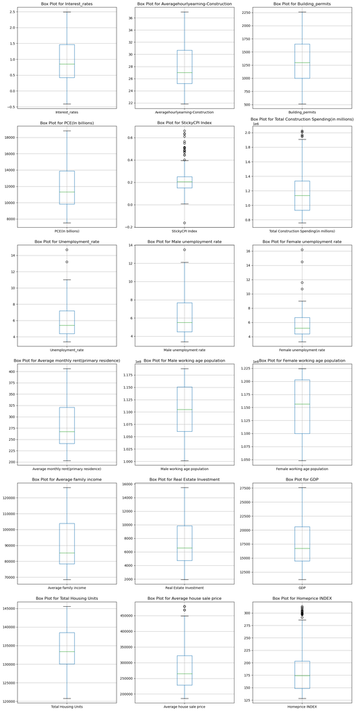

```python
numeric_columns = [column for column in df.columns if pd.api.types.is_numeric_dtype(df[column])]

# Number of subplots needed
num_plots = len(numeric_columns)

# Number of columns for the subplots
num_cols = 3  # Adjust this value based on your preference

# Calculate the number of rows needed
num_rows = -(-num_plots // num_cols)

# Creating subplots
fig, axes = plt.subplots(num_rows, num_cols, figsize=(15, 5 * num_rows))

# Flatten the axes array to handle different numbers of rows and columns
axes = axes.flatten()

# Plot each numeric column
for i, column in enumerate(numeric_columns):
    ax = axes[i]
    df.boxplot(column=column, ax=ax)
    ax.set_title(f'Box Plot for {column}')

# Remove empty subplots if there are any
for i in range(num_plots, num_rows * num_cols):
    fig.delaxes(axes[i])

plt.tight_layout()
plt.show()
```

### Analysis

From the above box plots. we can see a few features having outliers:

**StickyCPI (Consumer Price Index):** Outliers in StickyCPI may indicate significant changes in the prices of certain goods and services that are resistant to quick adjustments. It could be due to external factors such as economic crises, policy changes, or unique market conditions.

**Unemployment Rate, Male Unemployment Rate, Female Unemployment Rate**: Outliers in unemployment rates might reflect economic downturns or sudden increases in joblessness. These could be due to recessions, industry-specific challenges, or changes in labor force dynamics.The highest unemployment rate was in the year 2020 as that was the period when covid had strucks and company were laying off their employees in bulk.

**Average House Sale Price**: Outliers in house sale prices may be indicative of exceptional property transactions, such as high-end luxury sales or distressed property sales.

# Heatmap

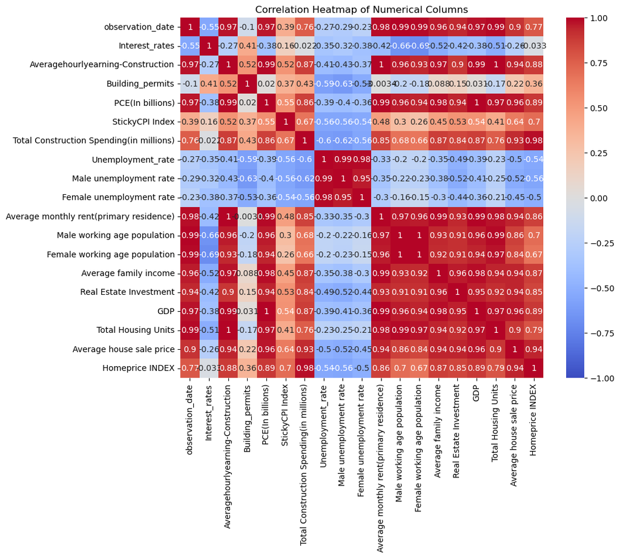

```python
correlation_matrix = df.corr()
plt.figure(figsize=(10, 8))
sns.heatmap(correlation_matrix, annot=True, cmap='coolwarm', vmin=-1, vmax=1)
plt.title('Correlation Heatmap of Numerical Columns')
plt.show()
```

### Analysis

From the above heatmap we can clearly see that there are a few features that are highly correlated. There are a few redundant columns like unemployment rate adn male unemployment rate and female unemployment rate that have high correlation which can lead to multicollinearity in the future. We can also see that there are a few features like Average house sale price which have good correlation with the target variable..

# Histograms

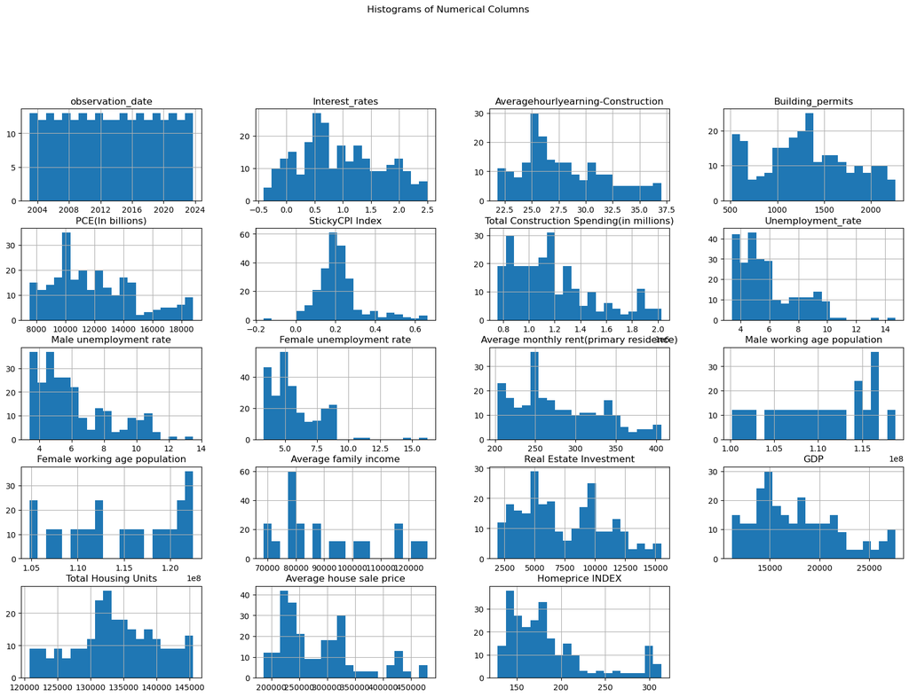

```python
df.hist(figsize=(20, 13), bins=20)
plt.suptitle('Histograms of Numerical Columns', y=1.02)
plt.show()
```

# How each feature effects the target variable:

**Real Interest Rates:** Influence: Low real interest rates reduce the cost of borrowing for homebuyers, fostering demand and potentially raising house prices. Investors, seeking better returns than offered by low-interest securities, may turn to real estate, further increasing demand and contributing to upward pressure on housing prices in the market. from the above graph we can also see a few negative values.A negative real interest rate occurs when the nominal interest rate on an investment or loan is lower than the inflation rate. In other words, after adjusting for inflation, the investor or borrower is effectively experiencing a decrease in purchasing power

**Average Hourly Earnings in Construction:** Influence: Higher average hourly earnings in the construction sector may indicate increased economic activity and demand for housing. Expected Effect: An increase in average hourly earnings in construction might contribute to an increase in HPI.

**Building Permits:** Influence: Higher numbers of building permits indicate increased construction activity, potentially leading to a larger housing supply. Expected Effect: An increase in building permits may contribute to an increase in HPI if demand outpaces supply.

**Personal Consumption Expenditure (PCE):** Influence: PCE reflects consumer spending, which can impact overall economic activity, including the real estate market. Expected Effect: Higher PCE might contribute to increased demand for housing and potentially an increase in HPI.

**StickyCPI Index:** Influence: StickyCPI measures the change in prices of goods and services that change slowly. It can influence inflation and the cost of living. Expected Effect: Higher StickyCPI might contribute to increased housing costs, potentially impacting HPI.

**Total Construction Spending:** Influence: Increased spending on construction can influence the supply of housing. Expected Effect: Higher construction spending might contribute to increased housing supply, potentially impacting HPI.

**Unemployment Rate, Male Unemployment Rate, Female Unemployment Rate:** Influence: Unemployment rates can impact consumer confidence and purchasing power. Expected Effect: Higher unemployment rates might lead to decreased demand for housing, potentially impacting HPI.

**Average Monthly Rent (Primary Residence):** Influence: Rental prices can influence the decision to buy or rent, impacting demand for housing. Expected Effect: Higher rental prices might contribute to increased demand for homeownership, potentially impacting HPI.

**GDP (Gross Domestic Product):** Influence: GDP reflects overall economic health and can impact consumer confidence. Expected Effect: Higher GDP might contribute to increased consumer confidence and demand for housing, potentially impacting HPI.

**Total Housing Units:** Influence: The total number of housing units can impact supply and demand dynamics. Expected Effect: A limited supply of housing units might contribute to increased HPI.

**Average House Sale Price:** Influence: The average sale price reflects the existing market conditions and buyer behavior. Expected Effect: Higher average house sale prices might contribute to increased HPI.

**Real Estate Investment:** Influence: Increased real estate investment can impact demand and supply dynamics. Expected Effect: Higher real estate investment might contribute to increased demand and potentially impact HPI.

# Scatter plot between StickyCPI Index and Unemployment rate

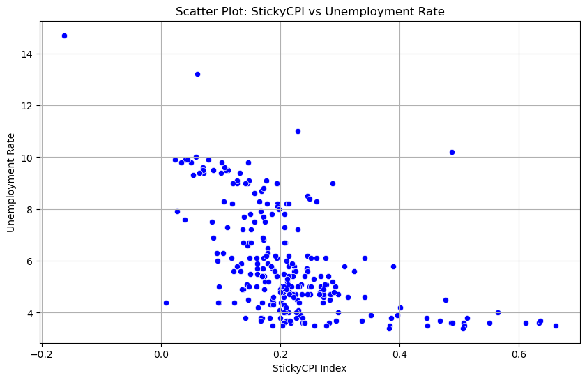

```python
import matplotlib.pyplot as plt
import seaborn as sns

# Assuming you have the correct column names in your dataset
plt.figure(figsize=(10, 6))
sns.scatterplot(x=df['StickyCPI Index'], y=df['Unemployment_rate'], color='blue')
plt.title('Scatter Plot: StickyCPI vs Unemployment Rate')
plt.xlabel('StickyCPI Index')
plt.ylabel('Unemployment Rate')
plt.grid(True)
plt.show()
```

### Analysis:

We can see that the points form kind of a **downward-sloping pattern**, it indicates a negative correlation. It's important to consider the broader economic context before casually making a relation between them, the specific factors driving changes in StickyCPI, and the dynamics of the labor market. But in our case, according to the graph plotted ,as StickyCPI increases, the Unemployment Rate tends to decrease

From the above picture we can see that there are some outlying points on the graph which may represent periods where StickyCPI and Unemployment Rate deviate significantly from the general trend.

# Line Graph Denoting changes in Interest over the years:

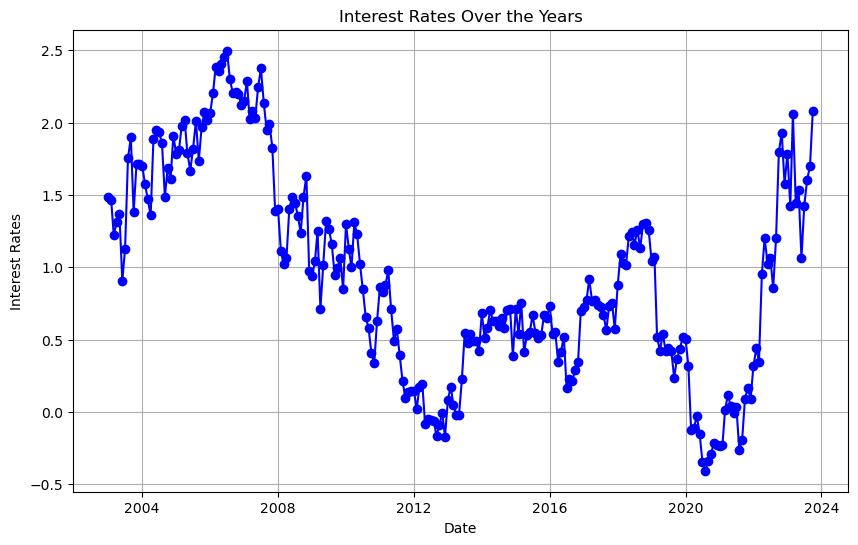

```python
import matplotlib.pyplot as plt
import pandas as pd

# Assuming 'Date' is the date column and 'interest_rates' is the interest rates column
# Convert 'Date' to datetime format if it's not already
# dataset['Date'] = pd.to_datetime(dataset['Date'])

# Plotting
plt.figure(figsize=(10, 6))
plt.plot(df['observation_date'], df['Interest_rates'], marker='o', linestyle='-', color='b')
plt.title('Interest Rates Over the Years')
plt.xlabel('Date')
plt.ylabel('Interest Rates')
plt.grid(True)
plt.show()
```

### Analysis:

From the above plot. it is evident that real interest rate fluctuate alot. but the real interest rates were at its highest in the year 2006. And the contributing factor was the **federal reserve's efforts to combat rising inflation**. The fed increased the interest rates to cool down the economy and keep inflation in check. And also there was a housing boom in the year 2006 and the fed wanted to prevent excessive risk taking in the housing market, which played a role in the decision to raise interest rates.

# GDP vs Real Estate Investment

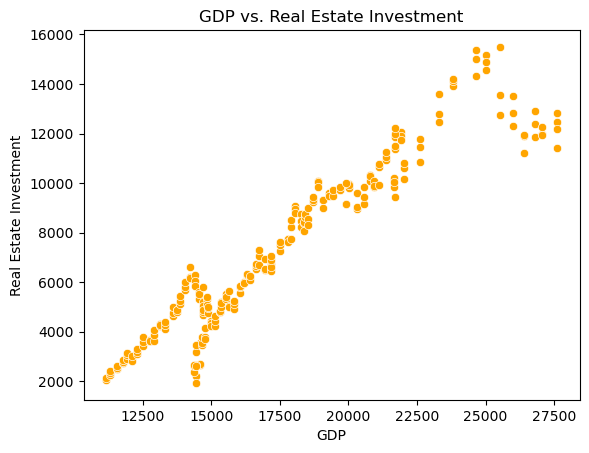

```python
sns.scatterplot(x='GDP', y='Real Estate Investment', data=df, color='orange')
plt.title('GDP vs. Real Estate Investment')
plt.xlabel('GDP')
plt.ylabel('Real Estate Investment')
plt.show()
```

### Analysis:

This scatter plot indicates **Positive Correlation** between real estate investment and the GDP: Since the points on the scatter plot tend to form an upward-sloping pattern, it suggests a positive correlation. This means that as Real estate investment increases, the GDP also tends to increase.

# Average monthly rent over the years:

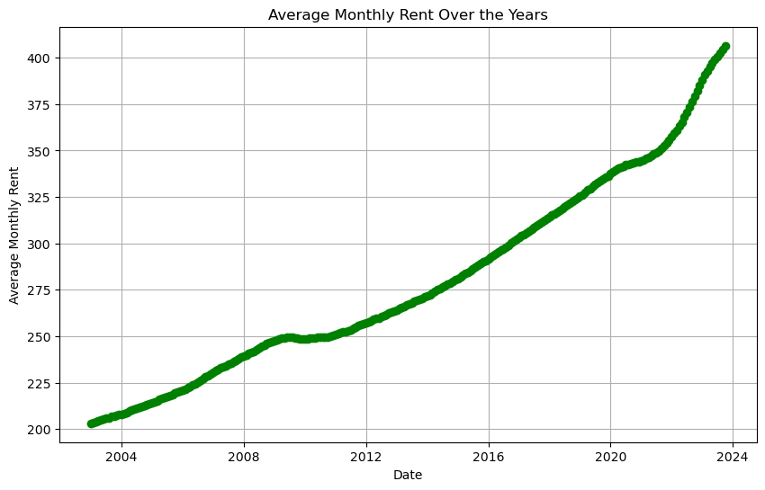

```python
plt.figure(figsize=(10, 6))
plt.plot(df['observation_date'], df['Average monthly rent(primary residence)'], marker='o', linestyle='-', color='green')
plt.title('Average Monthly Rent Over the Years')
plt.xlabel('Date')
plt.ylabel('Average Monthly Rent')
plt.grid(True)
plt.show()
```

### Analysis:

This above graph shows the average rent of primary residences over the years. It is evident from the graph that the average rent has kept on increasing steadily over the years.

# Unemployment rate (Male and female) Over the years:

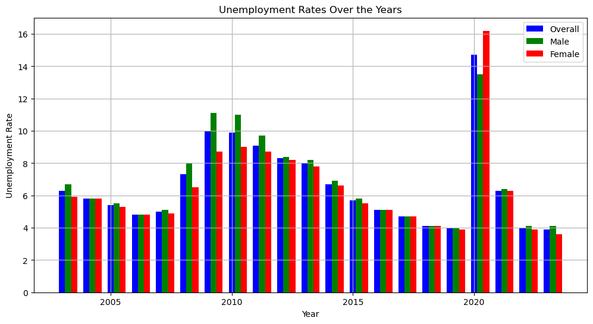

```python
import matplotlib.pyplot as plt
import pandas as pd

# Assuming 'Date', 'Unemployment_rate', 'Male unemployment rate', and 'Female unemployment rate' are columns
# Convert 'Date' to datetime format if it's not already
# dataset['Date'] = pd.to_datetime(dataset['Date'])

# Extract the year from the 'Date' column
df['Year'] = df['observation_date'].dt.year

plt.figure(figsize=(12, 6))

# Grouped bar plot for Unemployment Rate, Male Unemployment Rate, and Female Unemployment Rate
plt.bar(df['Year'], df['Unemployment_rate'], width=0.25, label='Overall', color='blue', align='center')
plt.bar(df['Year'] + 0.25, df['Male unemployment rate'], width=0.25, label='Male', color='green', align='center')
plt.bar(df['Year'] + 0.5, df['Female unemployment rate'], width=0.25, label='Female', color='red', align='center')

# X-axis labels
plt.xlabel('Year')

# Y-axis label
plt.ylabel('Unemployment Rate')

# Plot title
plt.title('Unemployment Rates Over the Years')

# Legend for different categories
plt.legend()

# Grid for better readability
plt.grid(True)

# Show the plot
plt.show()
```

# Analysis:

From the above graph, we can see that the unemployment rate was at its highest in the year 2020 which was the year when covid hit and companies were doing mass layoffs.

```python
df=df.dropna()
```

```python
df=df.drop(['observation_date'],axis=1)
```

#### Note:

From the above values we can see that there are a lot of featureswith very high values and a lot of features with low values which gives us a scope of performing different types of scaling in case the full model does not perform well.

**Types of scaling:**

**Min-Max Scaling:**

Explanation: Scales features to a specific range (usually between 0 and 1) by subtracting the minimum value and dividing by the range.

**Standard Scaling (Z-score normalization):**

Explanation: Standardizes features to have a mean of 0 and a standard deviation of 1 by subtracting the mean and dividing by the standard deviation.

```python
from sklearn.model_selection import train_test_split
```

```python
x=df.drop(['Homeprice INDEX'],axis=1)
y=df['Homeprice INDEX']
```

```python
x_train,x_test,y_train,y_test=train_test_split(x,y,test_size=0.2)
```

```python
train_data=x_train.join(y_train)
```

# Linear Regression:

```python
from sklearn.linear_model import LinearRegression
reg=LinearRegression()
```

```python
x_train,y_train=train_data.drop(['Homeprice INDEX'],axis=1),train_data['Homeprice INDEX']
```

```python
reg.fit(x_train,y_train)
```

```
LinearRegression()
```

```python
test_data=x_test.join(y_test)
```

```python
test_data.head()
```

|  | Interest_rates | Averagehourlyearning-Construction | Building_permits | PCE(In billions) | StickyCPI Index | Total Construction Spending(in millions) | Unemployment_rate | Male unemployment rate | Female unemployment rate | Average monthly rent(primary residence) | Male working age population | Female working age population | Average family income | Real Estate Investment | GDP | Total Housing Units | Average house sale price | Year | Homeprice INDEX |
| --- | --- | --- | --- | --- | --- | --- | --- | --- | --- | --- | --- | --- | --- | --- | --- | --- | --- | --- | --- |
| 123 | -0.024212 | 26.03 | 1012.0 | 11281.1 | 0.040427 | 879728.0 | 7.6 | 7.8 | 7.3 | 266.094 | 1.110127e+08 | 1.161778e+08 | 87670.0 | 7074.792273 | 16726.687 | 133408.0 | 268100.0 | 2013.0 | 151.517 |
| 121 | 0.172100 | 26.03 | 980.0 | 11290.5 | 0.172286 | 873583.0 | 7.7 | 7.8 | 7.6 | 264.904 | 1.110127e+08 | 1.161778e+08 | 87670.0 | 6645.972105 | 16648.189 | 133234.0 | 258400.0 | 2013.0 | 147.783 |
| 172 | 0.776409 | 28.73 | 1205.0 | 13171.9 | 0.123200 | 1282926.0 | 4.4 | 4.3 | 4.4 | 306.720 | 1.148283e+08 | 1.200982e+08 | 103200.0 | 9483.711364 | 19438.643 | 137083.0 | 318200.0 | 2017.0 | 189.615 |
| 105 | 0.098562 | 25.49 | 671.0 | 10802.9 | 0.171634 | 808378.0 | 8.8 | 9.2 | 8.4 | 255.651 | 1.090269e+08 | 1.127178e+08 | 81010.0 | 4928.241429 | 15842.259 | 132491.0 | 221100.0 | 2011.0 | 137.951 |
| 167 | 0.700457 | 28.43 | 1248.0 | 13005.9 | 0.214930 | 1270443.0 | 4.7 | 4.8 | 4.6 | 302.271 | 1.143026e+08 | 1.196361e+08 | 97360.0 | 9335.705714 | 19089.379 | 136554.0 | 310900.0 | 2016.0 | 185.718 |

```python
x_test,y_test=test_data.drop(['Homeprice INDEX'],axis=1),test_data['Homeprice INDEX']
```

```python
from sklearn.metrics import mean_squared_error,r2_score
```

```python
from sklearn.metrics import mean_squared_error

# Assuming you have predicted values and actual values for both training and test sets
y_pred_train = reg.predict(x_train)
y_pred_test = reg.predict(x_test)

# Evaluate the model
mse_train = mean_squared_error(y_train, y_pred_train)
mse_test = mean_squared_error(y_test, y_pred_test)
rmse_train = np.sqrt(mse_train)
rmse_test = np.sqrt(mse_test)
r2_test = r2_score(y_test, y_pred_test)
r2_train = r2_score(y_train, y_pred_train)


print(f'Mean Squared Error (Training Set): {mse_train}')
print(f'Mean Squared Error (Test Set): {mse_test}')
print(' ')
print(f'R-squared Score (Training Set): {r2_train}')
print(f'R-squared Score (Test Set): {r2_test}')
print(" ")
print(f"Root Mean Squared Error(Training Set): {rmse_train}")
print(f"Root Mean Squared Error(Test Set): {rmse_test}")
```

```
Mean Squared Error (Training Set): 6.626749518447677
Mean Squared Error (Test Set): 7.1877428380169395

R-squared Score (Training Set): 0.9961591711269719
R-squared Score (Test Set): 0.9965021310355482

Root Mean Squared Error(Training Set): 2.574247369319366
Root Mean Squared Error(Test Set): 2.6809966128320526
```

# Metrics:

The Linear Regression model gives us a near perfect model. It is because the data given to it consists of just 250 rows which is too less to train a machine learning model. The data that we have is too small for the machine learning model to learn.

**Metrics for evaluation:**

**Mean Squared error:**

We can say that the Model is performing steaddily on both training and test data set.

**Root Mean Squared error:**

We can say that the Model is performing steaddily on both training and test data set.

# Random Forest Regressor

```python
from sklearn.ensemble import RandomForestRegressor

forest=RandomForestRegressor()
```

```python
forest.fit(x_train,y_train)
```

```
RandomForestRegressor()
```

```python
from sklearn.metrics import mean_squared_error

# Assuming you have predicted values and actual values for both training and test sets
y_pred_train = forest.predict(x_train)
y_pred_test = forest.predict(x_test)

# Evaluate the model
mse_train = mean_squared_error(y_train, y_pred_train)
mse_test = mean_squared_error(y_test, y_pred_test)
rmse_train = np.sqrt(mse_train)
rmse_test = np.sqrt(mse_test)
r2_test = r2_score(y_test, y_pred_test)
r2_train = r2_score(y_train, y_pred_train)


print(f'Mean Squared Error (Training Set): {mse_train}')
print(f'Mean Squared Error (Test Set): {mse_test}')
print(' ')
print(f'R-squared Score (Training Set): {r2_train}')
print(f'R-squared Score (Test Set): {r2_test}')
print(" ")
print(f"Root Mean Squared Error(Training Set): {rmse_train}")
print(f"Root Mean Squared Error(Test Set): {rmse_test}")
```

```
Mean Squared Error (Training Set): 0.5813466645851142
Mean Squared Error (Test Set): 2.0742713712877228

R-squared Score (Training Set): 0.9996630545566327
R-squared Score (Test Set): 0.9989905691373511

Root Mean Squared Error(Training Set): 0.7624609265956611
Root Mean Squared Error(Test Set): 1.4402330961645489
```

### Metrics :

**Metrics for evaluation:**

**Mean Squared error:**

**Root Mean Squared Error:**

We can say that the Model is performing steaddily on both training and test data set.

# Decision Tree Regressor:

```python
from sklearn.tree import DecisionTreeRegressor
from sklearn.metrics import mean_squared_error, r2_score

# Initialize
tree_regressor = DecisionTreeRegressor(random_state=42)

# Train the model
tree_regressor.fit(x_train, y_train)

# Make predictions
y_pred_train = tree_regressor.predict(x_train)
y_pred_test = tree_regressor.predict(x_test)


# Evaluate the model
mse_train = mean_squared_error(y_train, y_pred_train)
mse_test = mean_squared_error(y_test, y_pred_test)
rmse_train = np.sqrt(mse_train)
rmse_test = np.sqrt(mse_test)
r2_test = r2_score(y_test, y_pred_test)
r2_train = r2_score(y_train, y_pred_train)


print(f'Mean Squared Error (Training Set): {mse_train}')
print(f'Mean Squared Error (Test Set): {mse_test}')
print(' ')
print(f'R-squared Score (Training Set): {r2_train}')
print(f'R-squared Score (Test Set): {r2_test}')
print(" ")
print(f"Root Mean Squared Error(Training Set): {rmse_train}")
print(f"Root Mean Squared Error(Test Set): {rmse_test}")
```

```
Mean Squared Error (Training Set): 0.0
Mean Squared Error (Test Set): 5.822115560975582

R-squared Score (Training Set): 1.0
R-squared Score (Test Set): 0.9971667047935445

Root Mean Squared Error(Training Set): 0.0
Root Mean Squared Error(Test Set): 2.41290604064385
```

# Metrics:

**Metrics For Evaluation:**

R-squared Score (Training Set): 1.0

**Mean Squared Error:**

Mean Squared Error (Training Set): 0.0

**Root Mean Squared Error:**

Root Mean Squared Error(Training Set): 0.0

# Extreme Gradient Boosting

```python
# pip install xgboost
```

```python
from xgboost import XGBRegressor
from sklearn.metrics import mean_squared_error, r2_score
from sklearn.model_selection import train_test_split


xgb_regressor = XGBRegressor(objective='reg:squarederror', random_state=42)

# Train the model
xgb_regressor.fit(x_train, y_train)

# Make predictions
y_pred_train = xgb_regressor.predict(x_train)
y_pred_test = xgb_regressor.predict(x_test)


# Evaluate the model
mse_train = mean_squared_error(y_train, y_pred_train)
mse_test = mean_squared_error(y_test, y_pred_test)
rmse_train = np.sqrt(mse_train)
rmse_test = np.sqrt(mse_test)
r2_test = r2_score(y_test, y_pred_test)
r2_train = r2_score(y_train, y_pred_train)


print(f'Mean Squared Error (Training Set): {mse_train}')
print(f'Mean Squared Error (Test Set): {mse_test}')
print(' ')
print(f'R-squared Score (Training Set): {r2_train}')
print(f'R-squared Score (Test Set): {r2_test}')
print(" ")
print(f"Root Mean Squared Error(Training Set): {rmse_train}")
print(f"Root Mean Squared Error(Test Set): {rmse_test}")
```

```
Mean Squared Error (Training Set): 1.1837157328493486e-06
Mean Squared Error (Test Set): 6.082227441635556

R-squared Score (Training Set): 0.9999999993139247
R-squared Score (Test Set): 0.9970401230146537

Root Mean Squared Error(Training Set): 0.0010879870095039503
Root Mean Squared Error(Test Set): 2.4662172332614083
```

# Metrics:

**Metrics For Evaluation:**

**Mean Squared Error:**

**Root Mean Squared Error:**

[figure not shown]

```python
from IPython.display import display, Image

image_path = "..\\files\\metrics.png"
display(Image(filename=image_path))
```

# Analysis: